# Analyse des données

### Bris de glace

```r
summary(freMPL5$ClaimNbWindscreen)
```

```
##    Min. 1st Qu.  Median    Mean 3rd Qu.    Max.
##  0.0000  0.0000  0.0000  0.4171  1.0000  8.0000
```

```r
quantile(freMPL5$ClaimNbWindscreen, seq(0,1,1/10))
```

```
##   0%  10%  20%  30%  40%  50%  60%  70%  80%  90% 100%
##    0    0    0    0    0    0    0    1    1    1    8
```

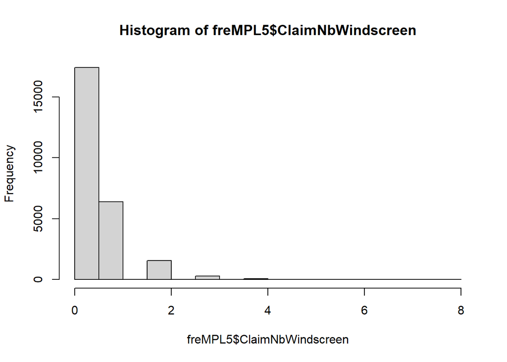

```r
hist(freMPL5$ClaimNbWindscreen)
```

L’évènement d’avoir au moins un bris de glace est relativement fréquent (environ 30%).

##### Etude par rapport à la sinistralité

```r
cor.test(freMPL5$ClaimNbWindscreen, as.numeric(freMPL5$ClaimInd))
```

```
##
##  Pearson's product-moment correlation
##
## data:  freMPL5$ClaimNbWindscreen and as.numeric(freMPL5$ClaimInd)
## t = 4.4163, df = 25720, p-value = 1.008e-05
## alternative hypothesis: true correlation is not equal to 0
## 95 percent confidence interval:
##  0.01531116 0.03973423
## sample estimates:
##        cor
## 0.02752681
```

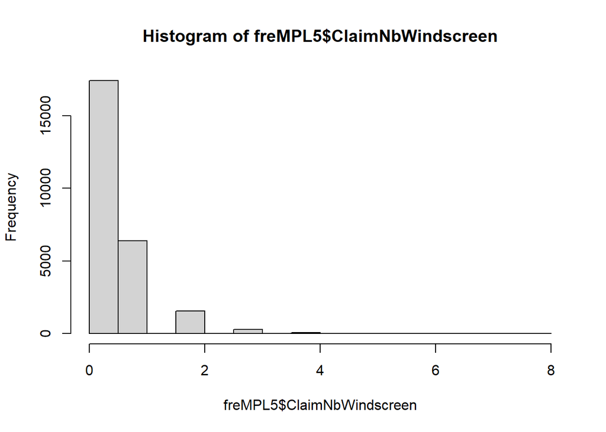

```r
hist(freMPL5$ClaimNbWindscreen)
```

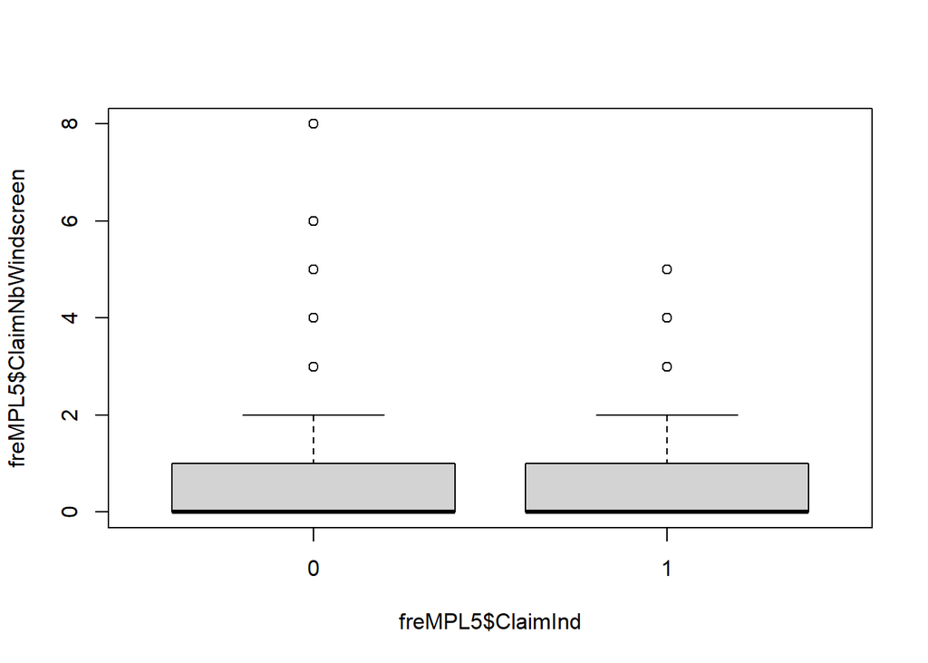

```r
boxplot(freMPL5$ClaimNbWindscreen ~ freMPL5$ClaimInd)
```

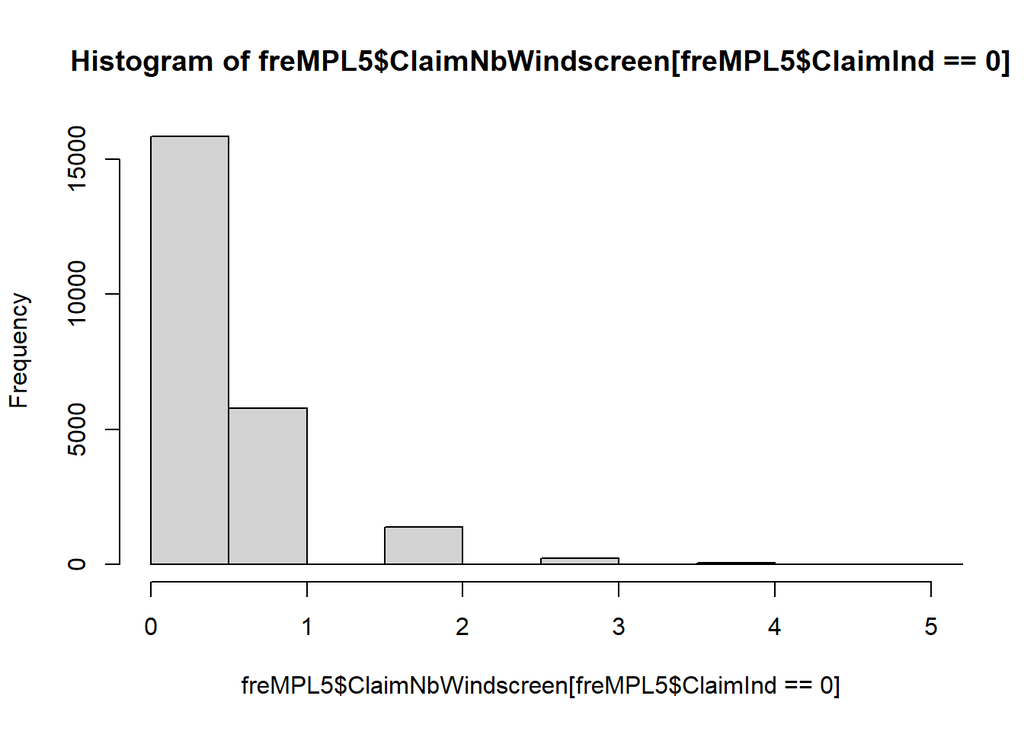

```r
hist(freMPL5$ClaimNbWindscreen[freMPL5$ClaimInd == 0], xlim=c(0,5))
```

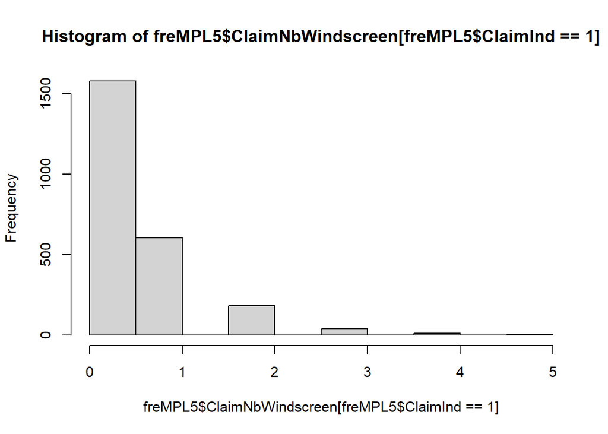

```r
hist(freMPL5$ClaimNbWindscreen[freMPL5$ClaimInd == 1])
```

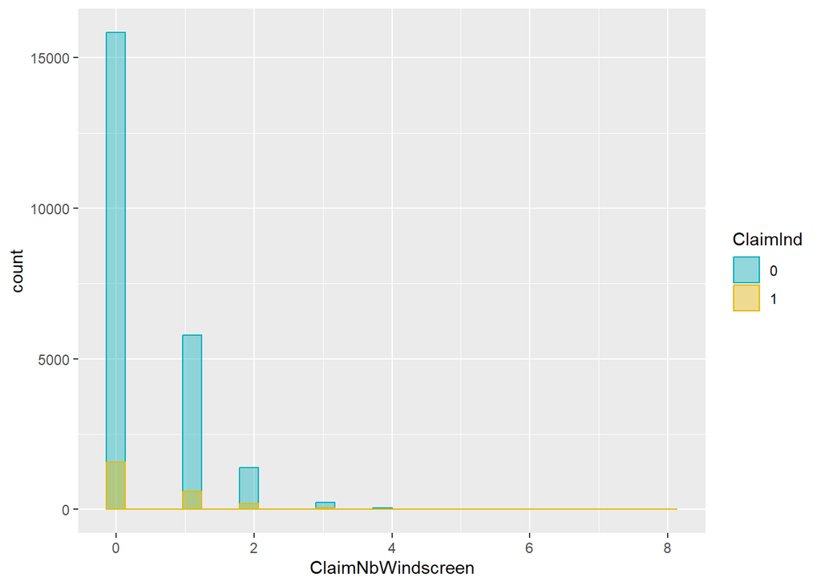

```r
ggplot(freMPL5, aes(x = ClaimNbWindscreen)) +
  geom_histogram(aes(color = ClaimInd, fill = ClaimInd),
                position = "identity", bins = 30, alpha = 0.4) +
  scale_color_manual(values = c("#00AFBB", "#E7B800")) +
  scale_fill_manual(values = c("#00AFBB", "#E7B800"))
```

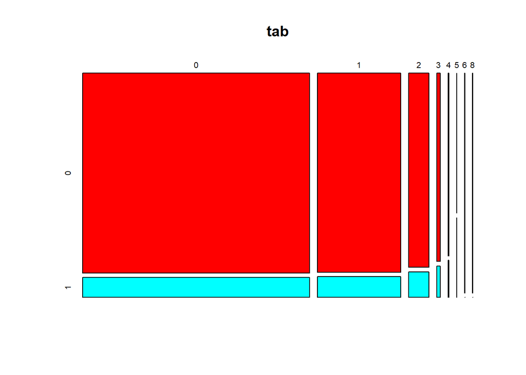

```r
tab <- table(freMPL5$ClaimNbWindscreen, freMPL5$ClaimInd)
cols <- rainbow(nlevels(freMPL5$ClaimInd))
plot(tab,col = cols)
```

Il y a ici aussi une petite corrélation. Avec les graphiques, on remarque qu’il y a plus d’indicateurs de réclamation positifs lors de birs de glace.

##### Etude par rapport au coût

```r
cor.test(freMPL5$ClaimNbWindscreen, freMPL5$ClaimAmount)
```

```
##
##  Pearson's product-moment correlation
##
## data:  freMPL5$ClaimNbWindscreen and freMPL5$ClaimAmount
## t = 0.43393, df = 25720, p-value = 0.6643
## alternative hypothesis: true correlation is not equal to 0
## 95 percent confidence interval:
##  -0.009515374  0.014926036
## sample estimates:
##         cor
## 0.002705735
```

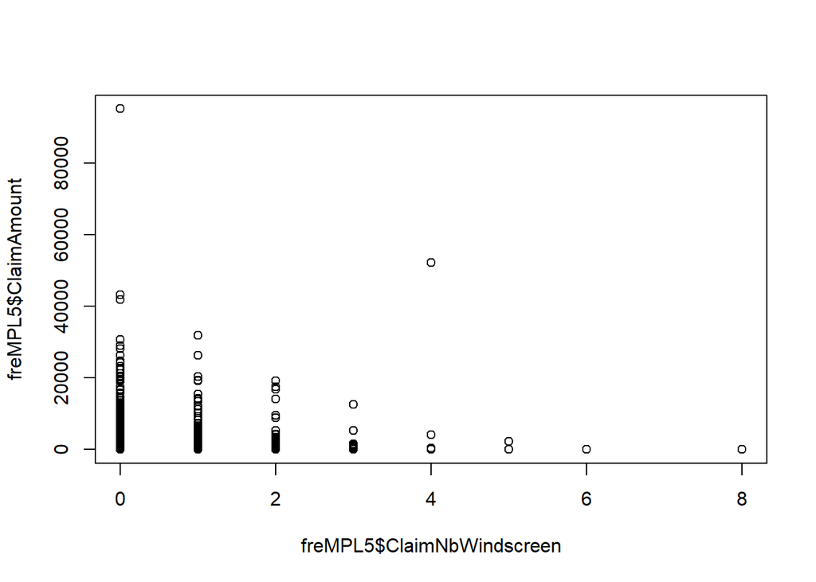

```r
plot(freMPL5$ClaimAmount ~ freMPL5$ClaimNbWindscreen)
```

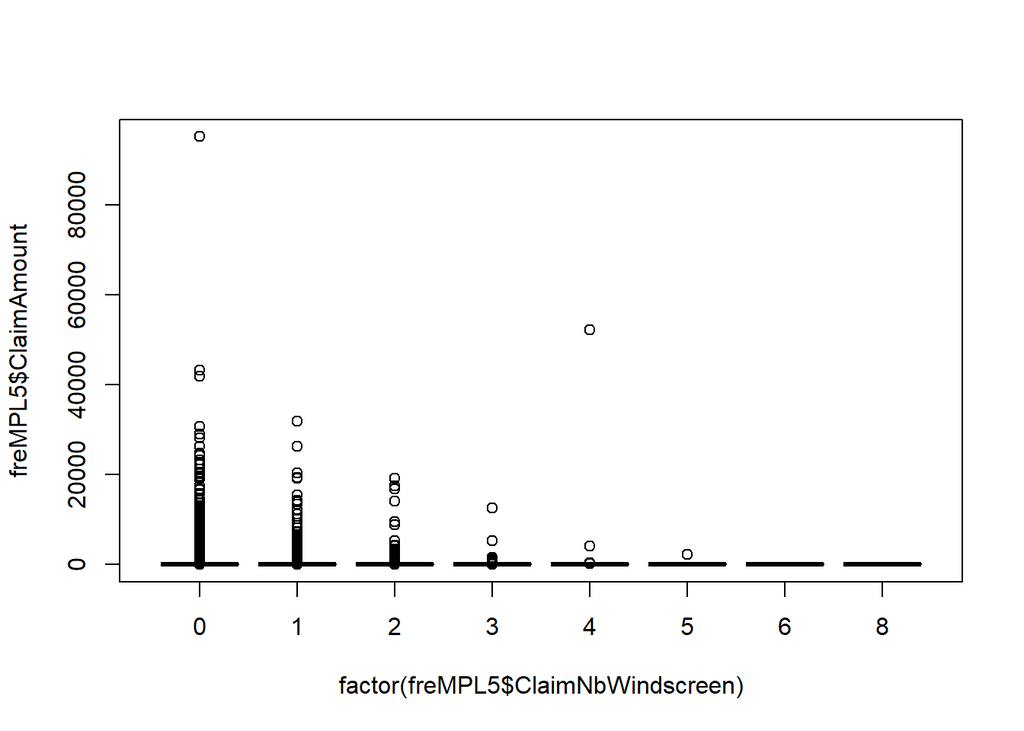

```r
boxplot(freMPL5$ClaimAmount ~ factor(freMPL5$ClaimNbWindscreen))
```

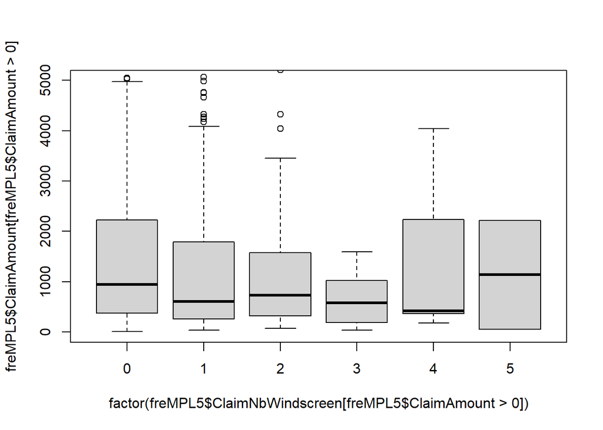

```r
boxplot(freMPL5$ClaimAmount[freMPL5$ClaimAmount>0] ~ factor(freMPL5$ClaimNbWindscreen[freMPL5$ClaimAmount>0]), ylim=c(0,5000))
```

Ici, la p-value ne nous donne pas un seuil de confiance acceptable pour rejeter l’hypothèse de non corrélation. On pourrait alors penser qu’il n’y a pas de corrélation (ou qu’elle est faible). Ceci pourrait s’expliquer grâce au fait que cela représente des faibles coûts comparés aux dégats que peuvent causer les autres accidents.

### Panne

```r
summary(freMPL5$OutUseNb)
```

```
##    Min. 1st Qu.  Median    Mean 3rd Qu.    Max.
##  0.0000  0.0000  0.0000  0.2245  0.0000  5.0000
```

```r
quantile(freMPL5$OutUseNb, seq(0,1,1/20))
```

```
##   0%   5%  10%  15%  20%  25%  30%  35%  40%  45%  50%  55%  60%  65%  70%  75%
##    0    0    0    0    0    0    0    0    0    0    0    0    0    0    0    0
##  80%  85%  90%  95% 100%
##    0    0    1    1    5
```

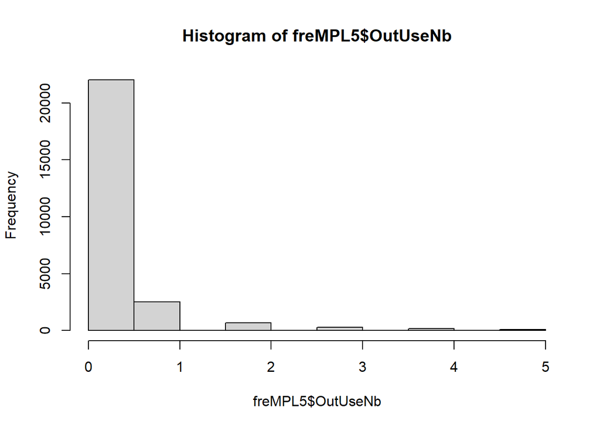

```r
hist(freMPL5$OutUseNb)
```

L’évènement d’avoir une panne est rare (environ 10%).

##### Etude par rapport à la sinistralité

```r
cor.test(freMPL5$OutUseNb, as.numeric(freMPL5$ClaimInd))
```

```
##
##  Pearson's product-moment correlation
##
## data:  freMPL5$OutUseNb and as.numeric(freMPL5$ClaimInd)
## t = 2.831, df = 25720, p-value = 0.004644
## alternative hypothesis: true correlation is not equal to 0
## 95 percent confidence interval:
##  0.005430188 0.029864163
## sample estimates:
##        cor
## 0.01764981
```

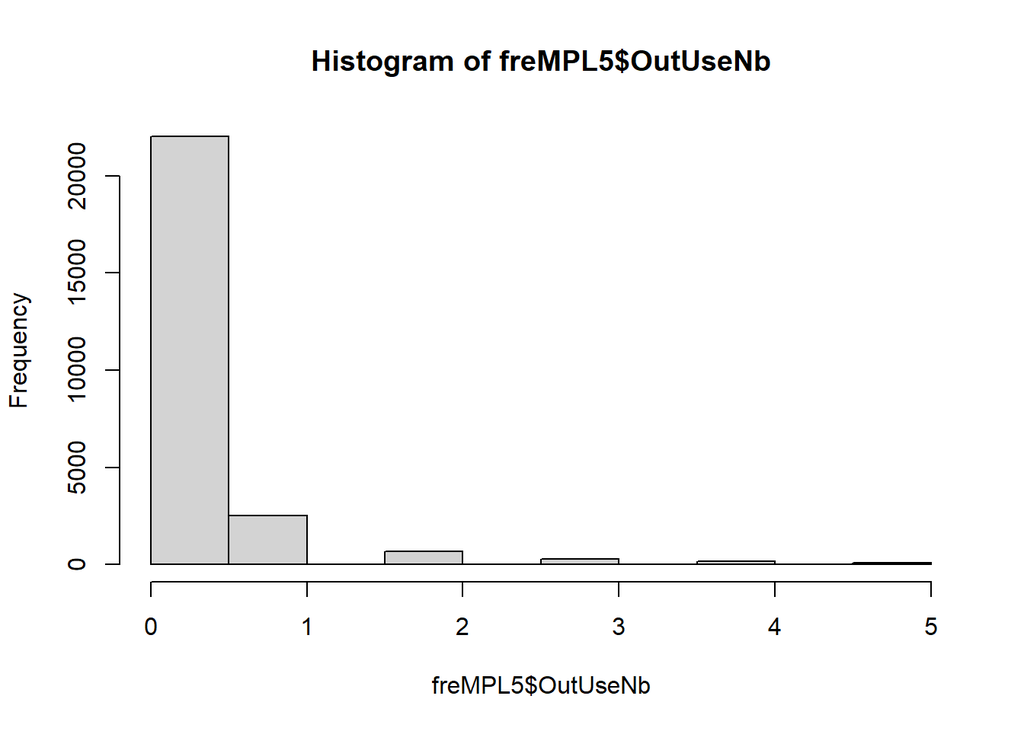

```r
hist(freMPL5$OutUseNb)
```

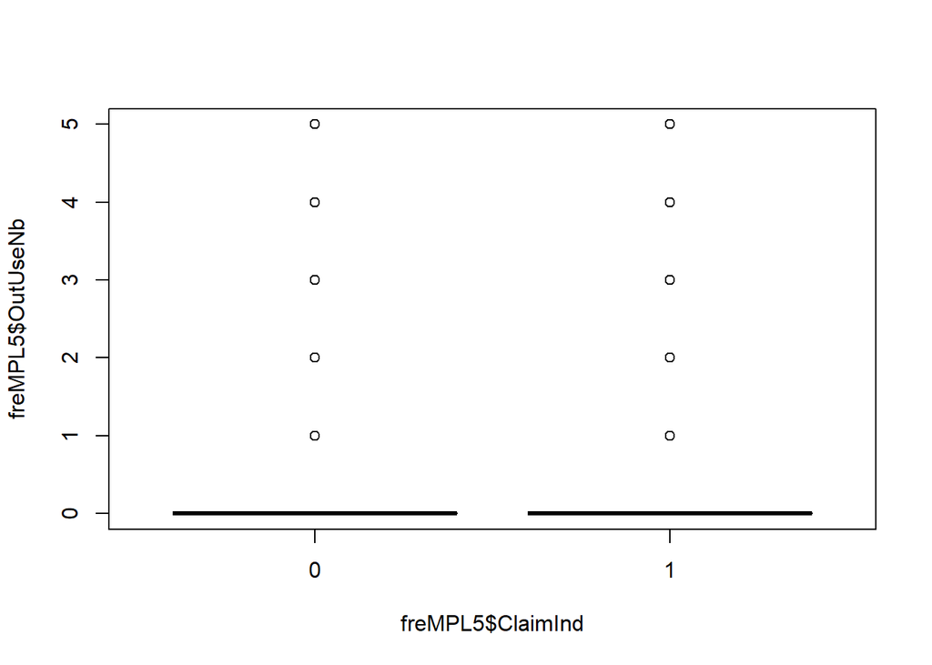

```r
boxplot(freMPL5$OutUseNb ~ freMPL5$ClaimInd)
```

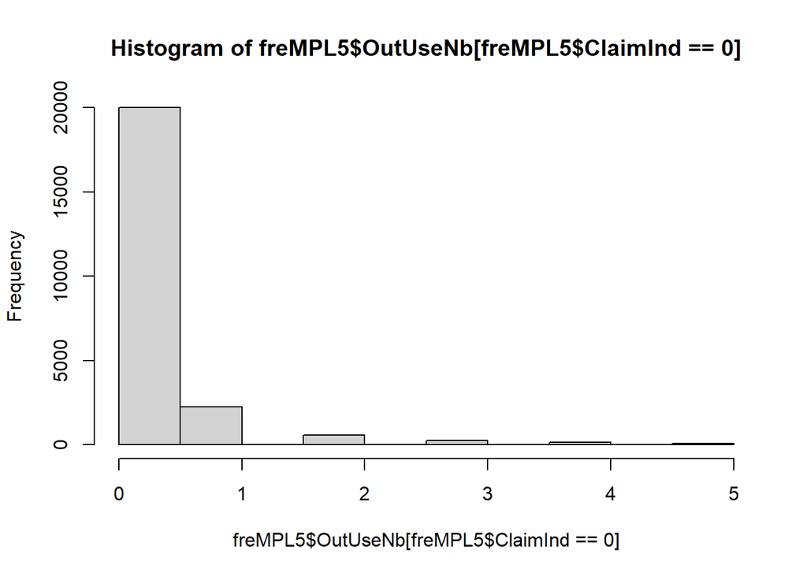

```r
hist(freMPL5$OutUseNb[freMPL5$ClaimInd == 0])
```

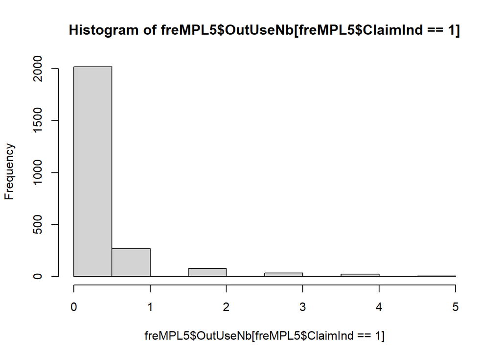

```r
hist(freMPL5$OutUseNb[freMPL5$ClaimInd == 1])
```

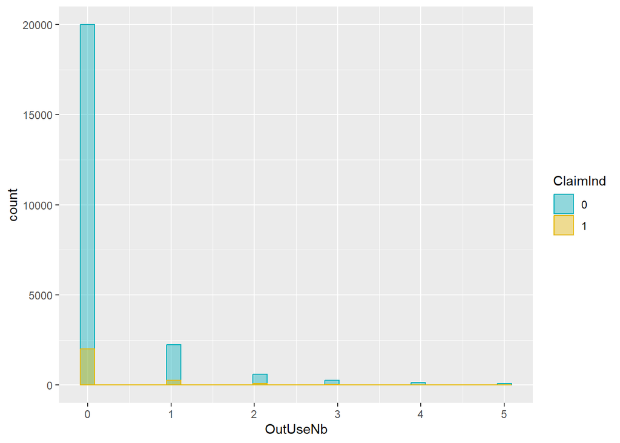

```r
ggplot(freMPL5, aes(x = OutUseNb)) +
  geom_histogram(aes(color = ClaimInd, fill = ClaimInd),
                position = "identity", bins = 30, alpha = 0.4) +
  scale_color_manual(values = c("#00AFBB", "#E7B800")) +
  scale_fill_manual(values = c("#00AFBB", "#E7B800"))
```

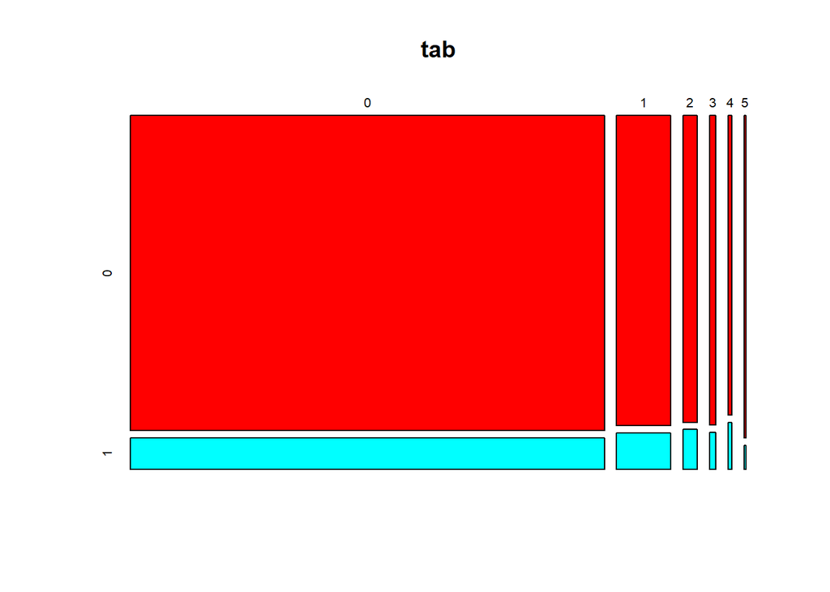

```r
tab <- table(freMPL5$OutUseNb, freMPL5$ClaimInd)
cols <- rainbow(nlevels(freMPL5$ClaimInd))
plot(tab,col = cols)
```

Il y a ici aussi une petite corrélation. Avec les graphiques, on remarque qu’il y a plus d’indicateurs de réclamation positifs lors de pannes.